# Project: Identify Customer Segments

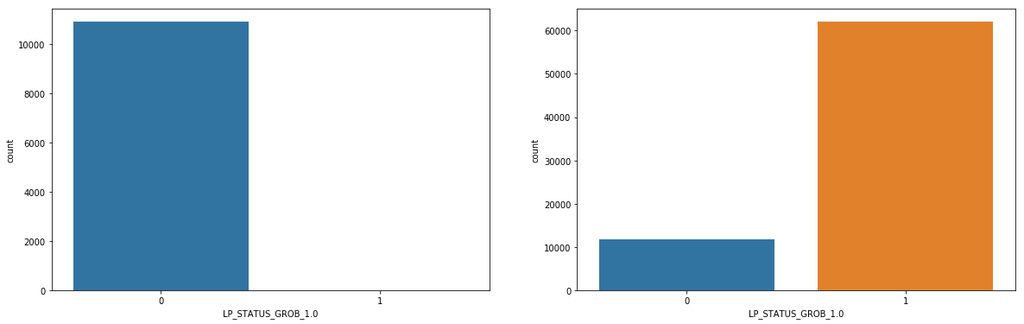

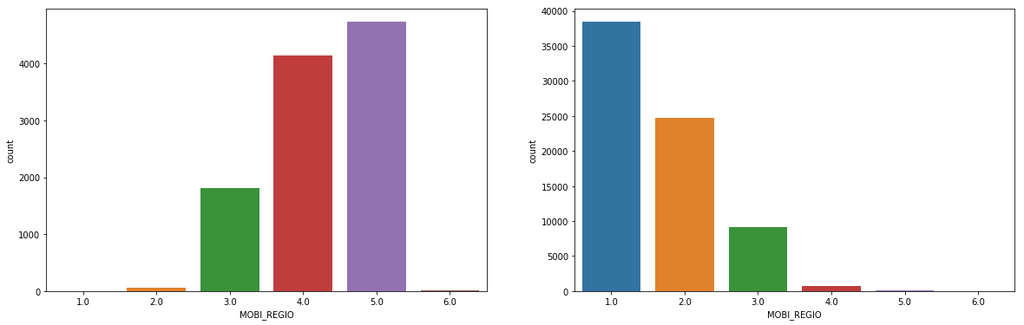

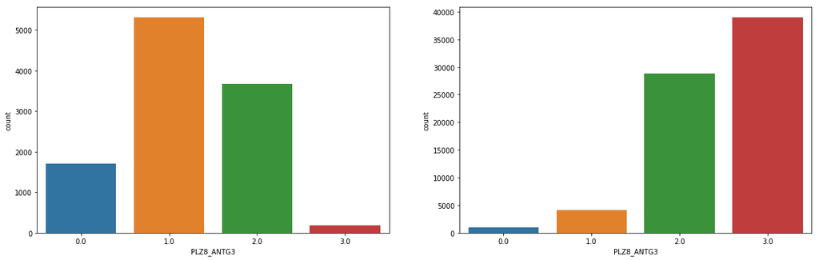

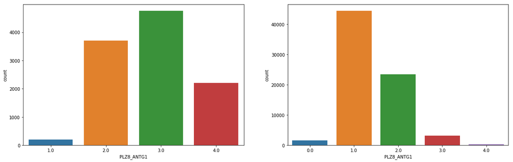

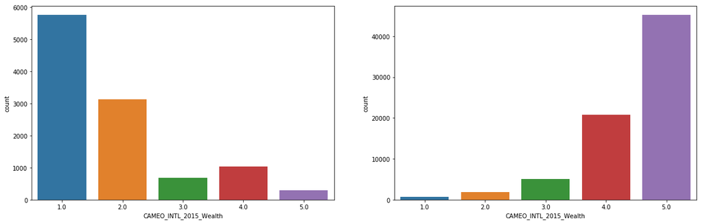

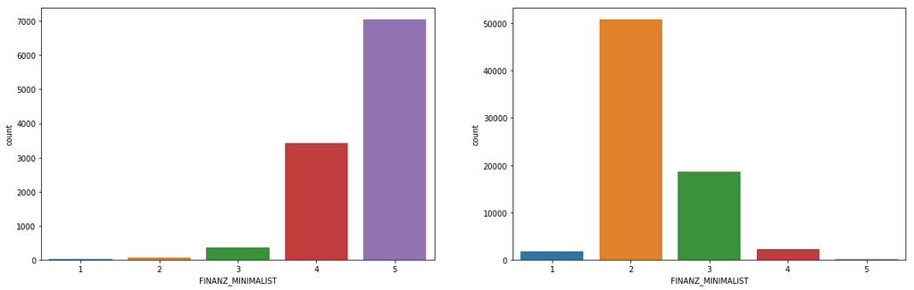

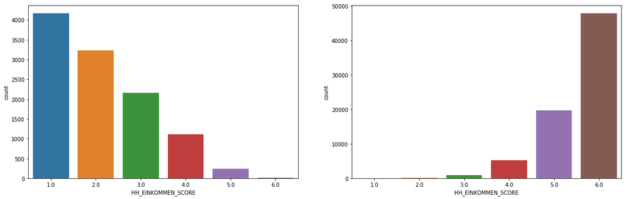

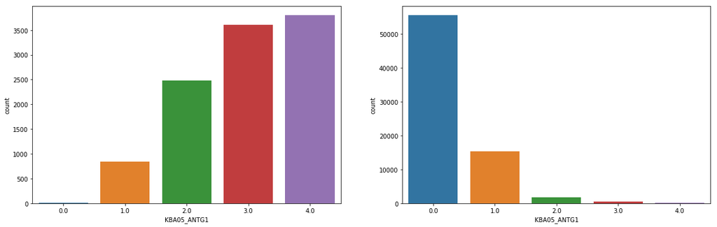

```python
# What kinds of people are part of a cluster that is underrepresented in the
# customer data compared to the general population?
def comparison_culsters_under(col):

# The least common segment in Customers dataset which are segment = 8 in order to compare with Genral
    cust_1 = customers_clu[col][customers_clu['segment'] == 8]

# The least common segment in Genral dataset which are segment = 13 in order to compare with Customers
    az_1 = az_clu[col][az_clu['segment'] == 13]
    fig, ax = plt.subplots(1,2,figsize=(20, 6))
    sns.countplot(cust_1,ax = ax[0])
    sns.countplot(az_1,ax = ax[1])

# Features in first components from our PCA analsys
featurs = ['LP_STATUS_GROB_1.0' ,  'MOBI_REGIO' , 'PLZ8_ANTG3' ,  'PLZ8_ANTG1',
           'CAMEO_INTL_2015_Wealth' ,  'FINANZ_MINIMALIST', 'HH_EINKOMMEN_SCORE' , 'KBA05_ANTG1']
for feat in featurs:
    comparison_culsters_under(feat)
```

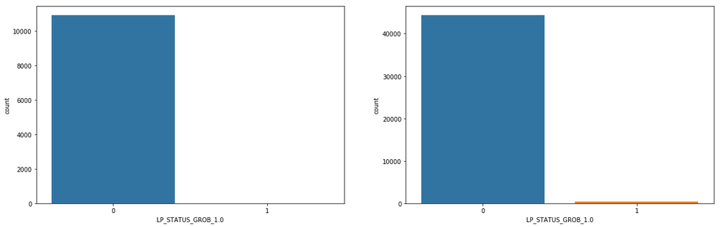

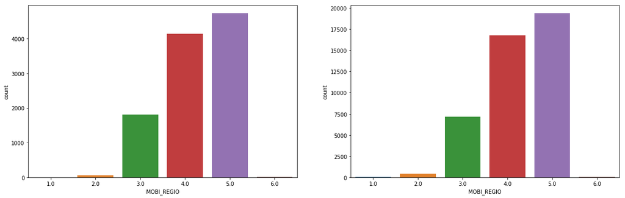

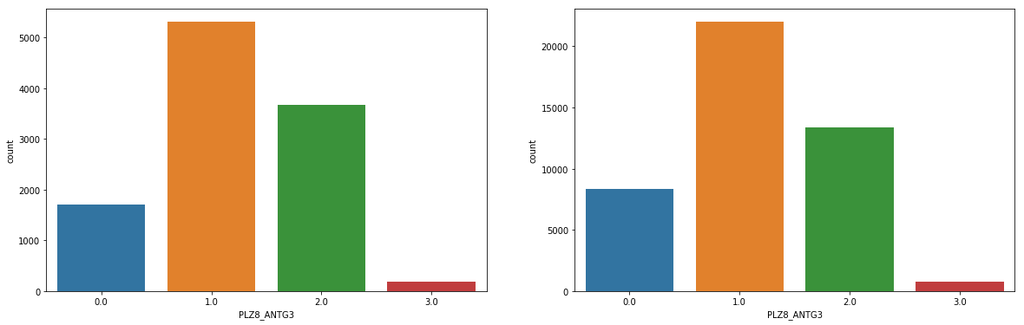

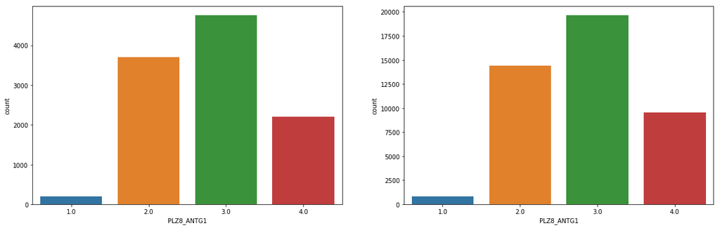

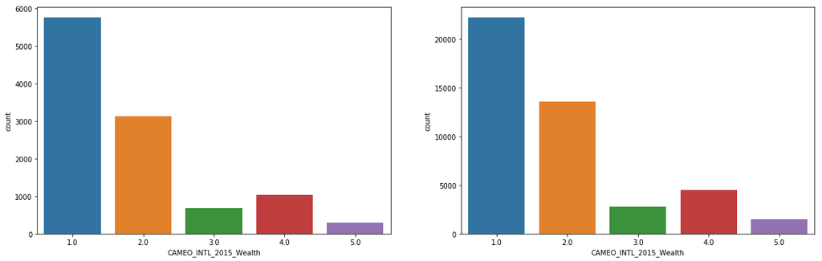

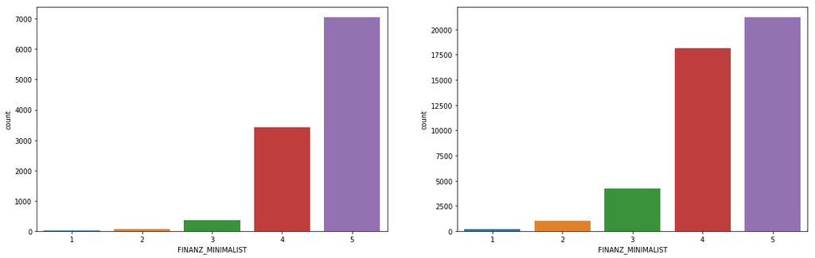

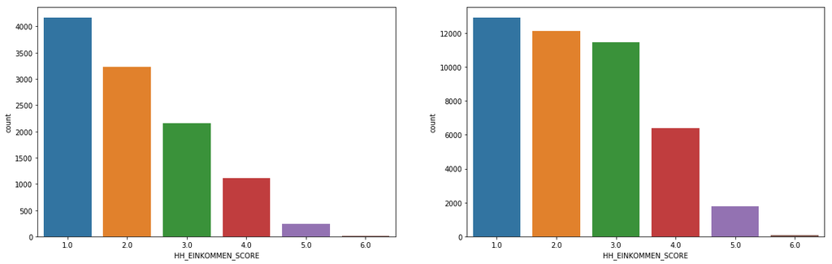

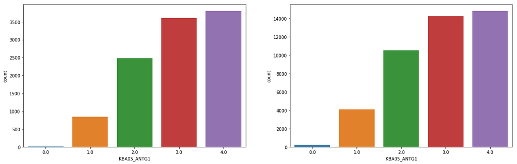

```python
def comparison_culsters_same(col):
    # Same segment
    cust_1 = customers_clu[col][customers_clu['segment'] == 8]
    az_1 = az_clu[col][az_clu['segment'] == 8]
    fig, ax = plt.subplots(1,2,figsize=(20, 6))
    sns.countplot(cust_1,ax = ax[0])
    sns.countplot(az_1,ax = ax[1])

# Features in first components from our PCA analsys
featurs = ['LP_STATUS_GROB_1.0' ,  'MOBI_REGIO' , 'PLZ8_ANTG3' ,  'PLZ8_ANTG1',
           'CAMEO_INTL_2015_Wealth' ,  'FINANZ_MINIMALIST', 'HH_EINKOMMEN_SCORE' , 'KBA05_ANTG1']
for feat in featurs:
    comparison_culsters_same(feat)
```

### Discussion 3.3: Compare Customer Data to Demographics Data

**After comparing the segments between Customer Data to Demographics Data, I found following:**

1.The segment most represented in the Customer Data is segment 1, which is classified as a segment with a high presence of the Demographics Data segments as well.

2.The lowest segment of Customer Data is segment 8, which is classified as having a high presence of the Demographics Data segments, which is worth to considering.

**After comparing the features the most important from our PCA analysis, between the most popular segments in Demographics Data segments 5 and the Customer Data segments 1, I found the following:**

1.For the feature Social status both segments 1 and 5 are not low-income earners.

2.For the feature Movement patterns for the segment 1 the most represented in the Customer Data are Middle Movement, which are classified as a few on the Demographics Data segment 5. But for the feature the most represented in the Demographics Data segment 5 is Very-low Movement, which are classified as a average in the Customer Data segment 1.

3.For the feature Number of 6-10 family for the segment 1 the most represented in the Customer Data are Average Share, which are classified as a average on the Demographics Data segment 5. But for the feature the most represented in the Demographics Data segment 5 is Lower Share, which are classified as a average in the Customer Data segment 1.

4.For the feature Wealth for the segment 1 the most represented in the Customer Data are Less-Affluent Households, which are classified as a low on the Demographics Data segment 5. But for the feature the most represented in the Demographics Data segment 5 is Wealthy Households, which are classified as a average in the Customer Data segment 1.

> Congratulations on making it this far in the project! Before you finish, make sure to check through the entire notebook from top to bottom to make sure that your analysis follows a logical flow and all of your findings are documented in **Discussion** cells. Once you've checked over all of your work, you should export the notebook as an HTML document to submit for evaluation. You can do this from the menu, navigating to **File -> Download as -> HTML (.html)**. You will submit both that document and this notebook for your project submission.